# 03 — Forecasting: Electricity Demand, Renewable Penetration & Emissions

## 8. Model Evaluation Summary

```python
# ── 8.1 Consolidated metrics table ───────────────────────────────────────────
metrics_df = pd.DataFrame(all_metrics)[['target', 'label', 'RMSE', 'MAPE', 'R2']]
metrics_df = metrics_df.sort_values(['target', 'MAPE'])

print('=== Full Model Evaluation Summary ===')
print(metrics_df.to_string(index=False))
print()
print('Lewis (1982) MAPE benchmarks: <10% = highly accurate, 10-20% = good, 20-50% = reasonable')

# Flag poor models
poor = metrics_df[metrics_df['MAPE'] > 20]
if len(poor) > 0:
    print(f'\n⚠ Models with MAPE > 20%:')
    print(poor[['label', 'MAPE']].to_string(index=False))
else:
    print('\n✓ All models achieve MAPE < 20%')
```

```
=== Full Model Evaluation Summary ===
                  target                            label   RMSE   MAPE      R2
CO₂ Intensity (gCO₂/kWh)     ARIMA(0, 0, 3) CO₂ Intensity 10.228  9.963  -0.921
            Demand (TWh)                  OLS (GDP + Pop) 15.574 21.070  -4.558
            Demand (TWh)                   ARIMA(3, 0, 1) 29.437 32.531 -18.858
        Fossil Gen (TWh)           ARIMA(1, 0, 3) (plain)  2.208  2.956   0.690
        Fossil Gen (TWh) ARIMAX(1, 0, 3) (+ policy dummy)  9.550 13.381  -4.802
      RE Penetration (%)    ARIMA(3, 1, 3) RE Penetration  3.078 34.115  -4.343

Lewis (1982) MAPE benchmarks: <10% = highly accurate, 10-20% = good, 20-50% = reasonable

⚠ Models with MAPE > 20%:
                        label   MAPE
              OLS (GDP + Pop) 21.070
               ARIMA(3, 0, 1) 32.531
ARIMA(3, 1, 3) RE Penetration 34.115
```

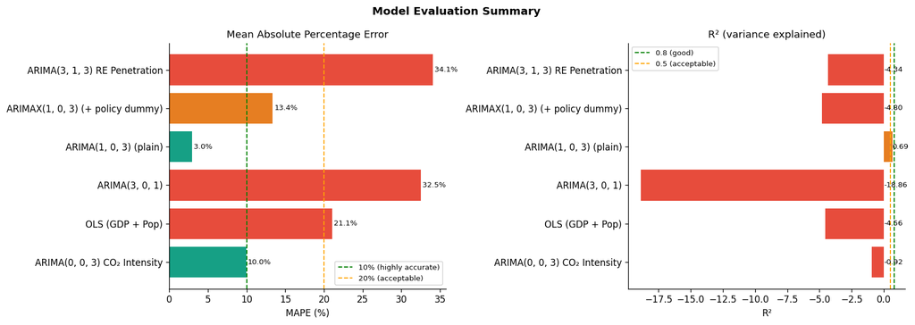

```python
# ── 8.2 Metrics visualisation ────────────────────────────────────────────────
fig, axes = plt.subplots(1, 2, figsize=(14, 5))
fig.suptitle('Model Evaluation Summary', fontweight='bold')

# MAPE by model
ax = axes[0]
bars = ax.barh(metrics_df['label'], metrics_df['MAPE'],
               color=[COLORS['accent'] if m < 10 else COLORS['scenario_mid'] if m < 20 else COLORS['co2']
                      for m in metrics_df['MAPE']])
ax.axvline(10, color='green',  ls='--', lw=1.2, label='10% (highly accurate)')
ax.axvline(20, color='orange', ls='--', lw=1.2, label='20% (acceptable)')
ax.set_xlabel('MAPE (%)')
ax.set_title('Mean Absolute Percentage Error')
ax.legend(fontsize=8)
for bar, val in zip(bars, metrics_df['MAPE']):
    ax.text(val + 0.2, bar.get_y() + bar.get_height()/2, f'{val:.1f}%', va='center', fontsize=8)

# R² by model
ax2 = axes[1]
bars2 = ax2.barh(metrics_df['label'], metrics_df['R2'],
                  color=[COLORS['accent'] if r > 0.8 else COLORS['scenario_mid'] if r > 0.5 else COLORS['co2']
                         for r in metrics_df['R2']])
ax2.axvline(0.8, color='green',  ls='--', lw=1.2, label='0.8 (good)')
ax2.axvline(0.5, color='orange', ls='--', lw=1.2, label='0.5 (acceptable)')
ax2.set_xlabel('R²')
ax2.set_title('R² (variance explained)')
ax2.legend(fontsize=8)
for bar, val in zip(bars2, metrics_df['R2']):
    ax2.text(max(val - 0.05, 0.01), bar.get_y() + bar.get_height()/2, f'{val:.2f}', va='center', fontsize=8)

plt.tight_layout()
plt.savefig('../outputs/03_model_evaluation.png', dpi=120, bbox_inches='tight')
plt.show()
```

## 9. Combined Forecast Dashboard

The four-panel dashboard below is the primary visual output of this notebook. It is designed to be included in the ILF advisory summary report and the Plotly Dash dashboard (notebook 07).

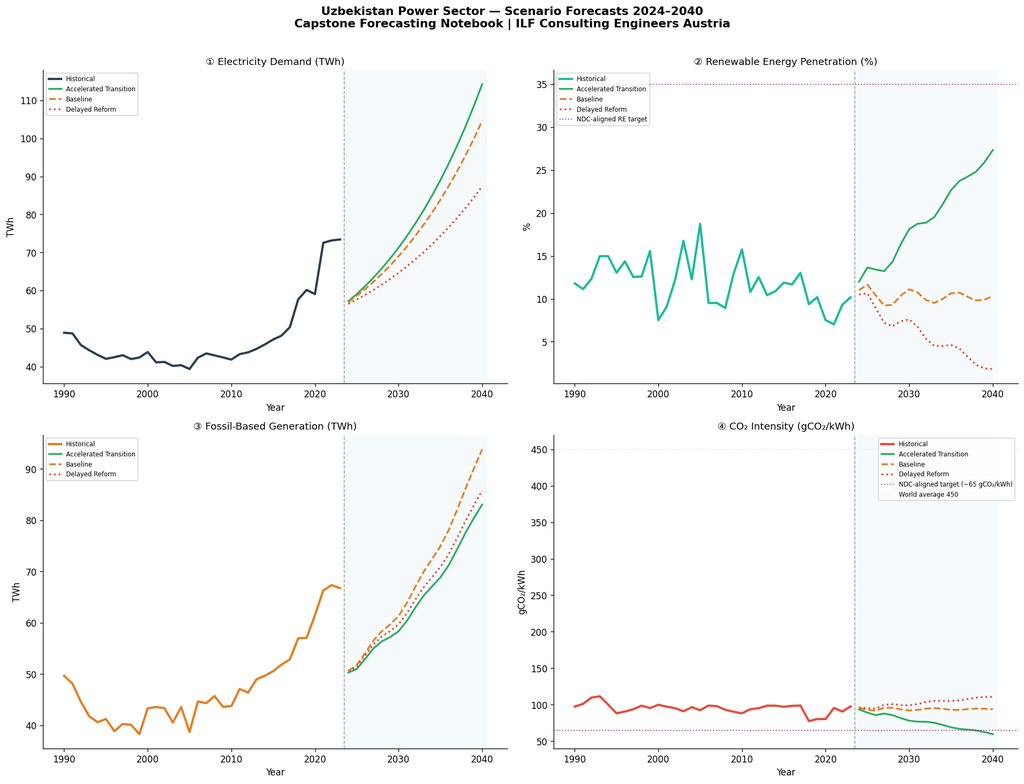

```
✓ Forecast dashboard saved to outputs/03_forecast_dashboard.png
```

```python
# ── 9.1 Full forecast dashboard ───────────────────────────────────────────────
SCENARIO_COLORS = {
    'Accelerated Transition': COLORS['scenario_low'],
    'Baseline':               COLORS['scenario_mid'],
    'Delayed Reform':         COLORS['scenario_high'],
}
SCENARIO_LS = {
    'Accelerated Transition': '-',
    'Baseline':               '--',
    'Delayed Reform':         ':',
}

fig, axes = plt.subplots(2, 2, figsize=(16, 12))
fig.suptitle('Uzbekistan Power Sector — Scenario Forecasts 2024–2040\n'
             'Capstone Forecasting Notebook | ILF Consulting Engineers Austria',
             fontsize=13, fontweight='bold', y=1.01)

# ── Panel 1: Electricity Demand ─────────────────────────────────────────────
ax = axes[0, 0]
hist_d = df_conf['elec_consumption_twh_bridged'].dropna()
ax.plot(hist_d.index, hist_d.values, color=COLORS['total'], lw=2.5, label='Historical')
for sc, path in demand_scenarios.items():
    ax.plot(fc_years, path.values, color=SCENARIO_COLORS[sc], ls=SCENARIO_LS[sc], lw=2, label=sc)
ax.axvline(2023.5, color='gray', ls='--', lw=1, alpha=0.7)
ax.set_title('① Electricity Demand (TWh)')
ax.set_ylabel('TWh')
ax.legend(fontsize=7, loc='upper left')
ax.yaxis.set_major_formatter(mticker.FuncFormatter(lambda x, _: f'{x:.0f}'))

# ── Panel 2: RE Penetration ──────────────────────────────────────────────────
ax2 = axes[0, 1]
hist_re = df_conf['re_penetration_pct'].dropna()
ax2.plot(hist_re.index, hist_re.values, color=COLORS['wind'], lw=2.5, label='Historical')
for sc, path in re_scenarios.items():
    ax2.plot(fc_years, path.values, color=SCENARIO_COLORS[sc], ls=SCENARIO_LS[sc], lw=2, label=sc)
ax2.axhline(35, color='purple', ls=':', lw=1.2, alpha=0.7, label='NDC-aligned RE target')
ax2.axvline(2023.5, color='gray', ls='--', lw=1, alpha=0.7)
ax2.set_title('② Renewable Energy Penetration (%)')
ax2.set_ylabel('%')
ax2.legend(fontsize=7, loc='upper left')

# ── Panel 3: Fossil Generation ───────────────────────────────────────────────
ax3 = axes[1, 0]
hist_fossil = df_conf['gen_fossil_twh'].dropna()

# Derive fossil scenarios from demand × (1 - RE share)
fossil_fc_scenarios = {}
for sc in demand_scenarios:
    re_frac = re_scenarios[sc] / 100
    fossil_fc_scenarios[sc] = demand_scenarios[sc] * (1 - re_frac)

ax3.plot(hist_fossil.index, hist_fossil.values, color=COLORS['gas'], lw=2.5, label='Historical')
for sc, path in fossil_fc_scenarios.items():
    ax3.plot(fc_years, path.values, color=SCENARIO_COLORS[sc], ls=SCENARIO_LS[sc], lw=2, label=sc)
ax3.axvline(2023.5, color='gray', ls='--', lw=1, alpha=0.7)
ax3.set_title('③ Fossil-Based Generation (TWh)')
ax3.set_ylabel('TWh')
ax3.legend(fontsize=7, loc='upper left')

# ── Panel 4: CO₂ Intensity ───────────────────────────────────────────────────
ax4 = axes[1, 1]
hist_co2 = df_conf['co2_intensity_power_gco2kwh'].dropna()
ax4.plot(hist_co2.index, hist_co2.values, color=COLORS['co2'], lw=2.5, label='Historical')
for sc, path in co2_scenarios.items():
    ax4.plot(fc_years, path.values, color=SCENARIO_COLORS[sc], ls=SCENARIO_LS[sc], lw=2, label=sc)
ax4.axhline(65, color='purple', ls=':', lw=1.2, alpha=0.7, label='NDC-aligned target (~65 gCO₂/kWh)')
ax4.axhline(450, color='lightgray', ls=':', lw=1, alpha=0.7, label='World average 450')
ax4.axvline(2023.5, color='gray', ls='--', lw=1, alpha=0.7)
ax4.set_title('④ CO₂ Intensity (gCO₂/kWh)')
ax4.set_ylabel('gCO₂/kWh')
ax4.legend(fontsize=7, loc='upper right')

# Legend for forecast horizon
for ax in axes.flat:
    ax.axvspan(2023.5, FC_HORIZON+0.5, alpha=0.04, color='steelblue')
    ax.set_xlabel('Year')

plt.tight_layout()
plt.savefig('../outputs/03_forecast_dashboard.png', dpi=130, bbox_inches='tight')
plt.show()

print('✓ Forecast dashboard saved to outputs/03_forecast_dashboard.png')
```

```python
# ── 9.2 Export forecast tables for dashboard (notebook 07) ───────────────────
import os
OUTPUT_DIR = '../outputs'
os.makedirs(OUTPUT_DIR, exist_ok=True)

for sc_name, sc_key in [
    ('baseline',     'Baseline'),
    ('accelerated',  'Accelerated Transition'),
    ('delayed',      'Delayed Reform'),
]:
    sc_df = pd.DataFrame({
        'year':                   fc_years,
        'demand_twh':             demand_scenarios[sc_key].values,
        're_penetration_pct':     re_scenarios[sc_key].values,
        'fossil_gen_twh':         fossil_fc_scenarios[sc_key].values,
        'co2_intensity_gco2kwh':  co2_scenarios[sc_key].values,
        'gdp_bn_usd_2015':        [scenario_gdp[sc_key][y] for y in fc_years],
        'pop_millions':           [pop_path[y]              for y in fc_years],
    })
    sc_df.to_csv(f'{OUTPUT_DIR}/03_forecast_{sc_name}.csv', index=False)
    print(f'✓ Saved: 03_forecast_{sc_name}.csv')

# Export metrics
metrics_df.to_csv(f'{OUTPUT_DIR}/03_model_metrics.csv', index=False)
print('✓ Saved: 03_model_metrics.csv')

print('\n=== Notebook 03 Complete ===')
print('Next: Notebook 04 — Investment Signals & ILF Advisory Mapping')
```

```
✓ Saved: 03_forecast_baseline.csv
✓ Saved: 03_forecast_accelerated.csv
✓ Saved: 03_forecast_delayed.csv
✓ Saved: 03_model_metrics.csv

=== Notebook 03 Complete ===
Next: Notebook 04 — Investment Signals & ILF Advisory Mapping
```

## Summary of Key Findings

[output not shown]

### Limitations & Next Steps

- **OLS spurious regression risk:** GDP and demand are both non-stationary. A cointegration test (Engle-Granger or Johansen) would confirm whether the long-run relationship is genuine. This is planned for the model validation annex.
- **ARIMA forecast uncertainty:** 15-year ARIMA forecasts carry wide confidence intervals. Scenario fan charts (plotted in the Dash dashboard) make this uncertainty visible to ILF stakeholders.
- **Plan B nuclear:** Uzbekistan's Rosatom SMRNPP commenced construction in 2024. A parametric nuclear overlay (+2.4 GW from 2033) is implemented in Notebook 07 as a sensitivity toggle.
- **Spatial dimension:** Demand forecasts are national totals. Oblast-level disaggregation using the spatial atlas data is implemented in Notebook 05.